# Prosodic Fingerprint

```r
library(tidyverse)
library(plyr)
library(ggplot2)
library(effects)
library(lmerTest)
library(Hmisc)
```

## Data preprocessing

```r
Unigram_data <- read_csv2("Unigrams.csv")
Unigram_data <- Unigram_data[-which(Unigram_data$Speaker_ID == "Speaker_ID"),]
nrow(Unigram_data)
```

```
## [1] 279153
```

```r
Unigram_data$Time_s <- as.double(Unigram_data$Time_s)
Unigram_data$Abs_value <- as.double(Unigram_data$Abs_value)
Unigram_data$Age <- as.double(Unigram_data$Age)
Unigram_data$Sex <- as.factor(Unigram_data$Sex)
#The functions define the boundaries of unigrams
cut_unigram <- function(Abs_value){
  unigrams <- cut(Abs_value, breaks = 3, labels = c(-1,0,1))
  return(unigrams)
}
cut_unigram_raw <- function(Abs_value){
  unigrams <- cut(Abs_value, breaks = 3)
  return(unigrams)
}

# Ordering the data by speaker
Unigram_data <- Unigram_data[order(Unigram_data$Speaker_ID),]
# Normalizing (Z-scaling the) absolute pitch value
Unigram_data$zAbs_value <- ave(as.numeric(Unigram_data$Abs_value), Unigram_data$Speaker_ID, FUN=scale)
# Cutting the unigrams into intervals
zUnigram_cut <- with(Unigram_data, tapply(zAbs_value, Speaker_ID,cut_unigram_raw))
zUnigram_raw <- c()

#Attaching normalized dataand intervals to the other data
for (element in zUnigram_cut){
  zUnigram_raw <- c(zUnigram_raw,as.character(element))
}
Unigram_data <- cbind(Unigram_data,zUnigram_raw)

#Counting z-normalized unigrams
zUnigram_cut <- with(Unigram_data, tapply(zAbs_value, Speaker_ID,cut_unigram))
zUnigram <- c()
for (element in zUnigram_cut){
  zUnigram <- c(zUnigram,as.character(element))
}
Unigram_data <- cbind(Unigram_data,zUnigram)
Unigram_data$Unigram <- as.factor(Unigram_data$Unigram)
Unigram_data$zUnigram <- as.factor(Unigram_data$zUnigram)
#levels(Unigram_data$zUnigram)

#Calculating deltas and normalized deltas
zDelta <- diff(as.numeric(zUnigram))
zDelta <- c(NA,zDelta)
Unigram_data <- cbind(Unigram_data,zDelta)
Delta <- diff(as.numeric(Unigram_data$Unigram))
Delta <- c(NA,Delta)

#attaching the deltas to the data
Unigram_data <- cbind(Unigram_data,Delta)
Unigram_data$Delta <- as.factor(Unigram_data$Delta)
Unigram_data$zDelta <- as.factor(Unigram_data$zDelta)

# Creating unique ID's for each sentence
Unigram_data <- cbind(paste(Unigram_data$Speaker_ID,Unigram_data$Sentence),Unigram_data)
colnames(Unigram_data)[1] <- "ID"
Unigram_data$ID <- as.factor(Unigram_data$ID)
#Unigram_data$Unigram <- as.factor(Unigram_data$Unigram)

# Counting raw unigrams
df <- with(Unigram_data, tapply(Unigram, ID, plyr::count))
Raw_Ug_Counted <- ldply(df, data.frame)
Raw_Ug_Counted <- spread(Raw_Ug_Counted, x, freq)
colnames(Raw_Ug_Counted)[1] <- "ID"

Raw_Ug_Counted$Speaker_ID <- Unigram_data$Speaker_ID[match(Raw_Ug_Counted$ID, Unigram_data$ID)]
Raw_Ug_Counted$Sex <- Unigram_data$Sex[match(Raw_Ug_Counted$ID, Unigram_data$ID)]
Raw_Ug_Counted$Age <- Unigram_data$Age[match(Raw_Ug_Counted$ID, Unigram_data$ID)]
Raw_Ug_Counted$Place <- Unigram_data$Place[match(Raw_Ug_Counted$ID, Unigram_data$ID)]
Raw_Ug_Counted$Text <- Unigram_data$Text[match(Raw_Ug_Counted$ID, Unigram_data$ID)]
Raw_Ug_Counted$Sentence <- Unigram_data$Sentence[match(Raw_Ug_Counted$ID, Unigram_data$ID)]

#Counting raw deltas
bdf <- with(Unigram_data, tapply(Delta, ID, plyr::count), default = 0)
Raw_Dlt_Counted <- ldply(bdf, data.frame)
Raw_Dlt_Counted <- spread(Raw_Dlt_Counted, x, freq)
colnames(Raw_Dlt_Counted)[1] <- "ID"

Raw_Dlt_Counted$Speaker_ID <- Unigram_data$Speaker_ID[match(Raw_Ug_Counted$ID, Unigram_data$ID)]
Raw_Dlt_Counted$Sex <- Unigram_data$Sex[match(Raw_Ug_Counted$ID, Unigram_data$ID)]
Raw_Dlt_Counted$Age <- Unigram_data$Age[match(Raw_Ug_Counted$ID, Unigram_data$ID)]
Raw_Dlt_Counted$Place <- Unigram_data$Place[match(Raw_Ug_Counted$ID, Unigram_data$ID)]
Raw_Dlt_Counted$Text <- Unigram_data$Text[match(Raw_Ug_Counted$ID, Unigram_data$ID)]
Raw_Dlt_Counted$Sentence <- Unigram_data$Sentence[match(Raw_Ug_Counted$ID, Unigram_data$ID)]

#Counting z-normalised Unigrams
zdf <- with(Unigram_data, tapply(zUnigram, ID, plyr::count))
zUg_Counted <- ldply(zdf, data.frame)
zUg_Counted <- spread(zUg_Counted, x, freq)
zUg_Counted[is.na(zUg_Counted)] <- 0
colnames(zUg_Counted)[1] <- "ID"

zUg_Counted$Speaker_ID <- Unigram_data$Speaker_ID[match(Raw_Ug_Counted$ID, Unigram_data$ID)]
zUg_Counted$Sex <- Unigram_data$Sex[match(Raw_Ug_Counted$ID, Unigram_data$ID)]
zUg_Counted$Age <- Unigram_data$Age[match(Raw_Ug_Counted$ID, Unigram_data$ID)]
zUg_Counted$Place <- Unigram_data$Place[match(Raw_Ug_Counted$ID, Unigram_data$ID)]
zUg_Counted$Text <- Unigram_data$Text[match(Raw_Ug_Counted$ID, Unigram_data$ID)]
zUg_Counted$Sentence <- Unigram_data$Sentence[match(Raw_Ug_Counted$ID, Unigram_data$ID)]

#Counting z-normalized Deltas
zbdf <- with(Unigram_data, tapply(zDelta, ID, plyr::count))
zDlt_Counted <- ldply(zbdf, data.frame)
zDlt_Counted <- spread(zDlt_Counted, x, freq)
zDlt_Counted[is.na(zDlt_Counted)] <- 0
colnames(zDlt_Counted)[1] <- "ID"

zDlt_Counted$Speaker_ID <- Unigram_data$Speaker_ID[match(Raw_Ug_Counted$ID, Unigram_data$ID)]
zDlt_Counted$Sex <- Unigram_data$Sex[match(Raw_Ug_Counted$ID, Unigram_data$ID)]
zDlt_Counted$Age <- Unigram_data$Age[match(Raw_Ug_Counted$ID, Unigram_data$ID)]
zDlt_Counted$Place <- Unigram_data$Place[match(Raw_Ug_Counted$ID, Unigram_data$ID)]
zDlt_Counted$Text <- Unigram_data$Text[match(Raw_Ug_Counted$ID, Unigram_data$ID)]
zDlt_Counted$Sentence <- Unigram_data$Sentence[match(Raw_Ug_Counted$ID, Unigram_data$ID)]
```

## Exploratory plots

Figure 1. Pitch sub-ranges in a recording sample

```r
Unigram_data$Time_s <- as.numeric(Unigram_data$Time_s)
Unigram_data$Abs_value <- as.numeric(Unigram_data$Abs_value)
Unigram_data$ID <- as.character(Unigram_data$ID)
subset(Unigram_data, Unigram_data$ID %in% c("AnnaSh 2")) %>%
  ggplot(aes(Time_s, Abs_value))+
  xlab("Time")+
  ylab("Pitch Value")+
  geom_hline(aes(yintercept=85.56109814999999), color = "red")+
  geom_hline(aes(yintercept=220.06107974516), color = "blue")+
  geom_hline(aes(yintercept=354.56106134032), color = "blue")+
  geom_hline(aes(yintercept=489.06104293548003), color = "red")+
  annotate(geom="text", x = 1,
           y = 75.56109814999999, label = "Outliers", colour='red', size = 3) +
  annotate(geom="text", x = 1,
           y = 150, label = "-1", colour='blue', size = 4) +
  annotate(geom="text", x = 1,
           y = 300, label = "0", colour='blue', size = 4) +
  annotate(geom="text", x = 1,
           y = 450, label = "1", colour='blue', size = 4) +
  annotate(geom="text", x = 1,
           y = 498.06104293548003, label = "Outliers", colour='red', size = 3) +
  #xlim(min(Unigram_data[Unigram_data$ID == "AnnaSh 10",]$Time_s), max(Unigram_data[Unigram_data$ID == "AnnaSh 10",]$Time_s))+
  xlim(93.5,96.5)+
  geom_line()+
  #facet_wrap(. ~ ID)+
  theme_bw() -> Fig1
```

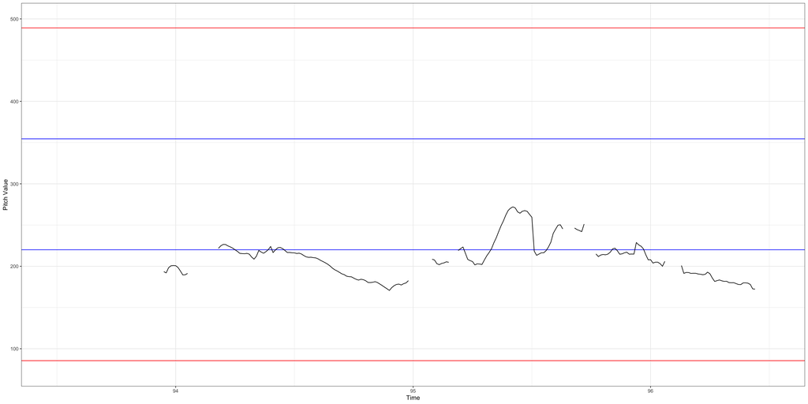

```r
Fig1
```

### Figure 2 (corrected age groups). The Distribution of the z-scored Unigram Values by Place, Sex and Age

After the text was published, I noticed a small mistake in the group names. The age groups should be named “≤40” instead of “25-40” and “>40” instead of “45+”. The mistake follows from the data collection protocol that we developed at some point. Since the current case study is partly based on the data collected before the protocol was established, the speakers could not be divided into such groups and I used 40 years as the cut-off point, but the plot titles and the description in the text were not changed accordingly. The mistake does not affect the counts and modelling. This grouping is only used for convenience in barplots, where age cannot be treated as a numeric variable; the models treat in as numeric. In the two plots below, the mistake has been corrected.

```r
Unigram_data <- mutate(Unigram_data, Age_Group = as.factor(ifelse(Unigram_data$Age <= 40,"25-40 (corrected: ≤ 40 )","45+ (corrected: >40)")))
Unigram_data$Place_1 <- factor(Unigram_data$Place, levels = c("Krasnoyarsk", "Nakhodka", "Novosibirsk", "Moscow" ))
subset(Unigram_data, !is.na(zUnigram)) %>%
  ggplot(aes(zUnigram, color=Place, fill=Place))+
  geom_bar(stat = "count", position="dodge")+
  xlab("Distribution of unigrams by Place, Sex and Age")+
  ylab("Number of unigrams of each type")+
  facet_wrap(~Place_1:Sex:Age_Group) -> Fig2
```

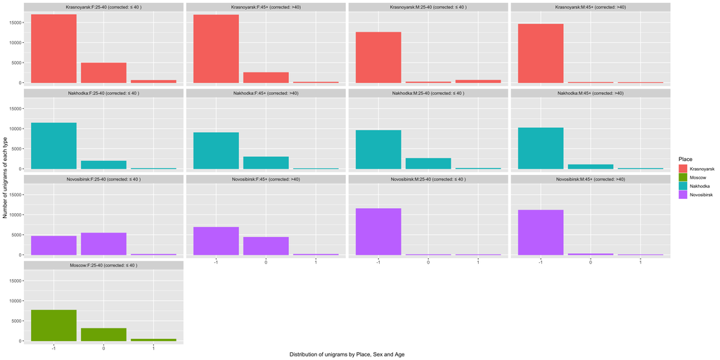

```r
Fig2
```

### Figure 3 (corrected age groups). The Distribution of the z-scored Delta Values by Place, Sex and Age

```r
zhist <- subset(Unigram_data, !is.na(zDelta))
zhist <- zhist[zhist$zDelta != 0,]
subset(zhist, !is.na(zDelta)) %>%
  ggplot(aes(zDelta, color=Place, fill=Place))+
  geom_bar(stat = "count", position="dodge")+
  xlab("Distribution of deltas by Place, Sex and Age")+
  ylab("Number of deltas of each type")+
  facet_wrap(~Place_1:Sex:Age_Group) -> Fig3
```

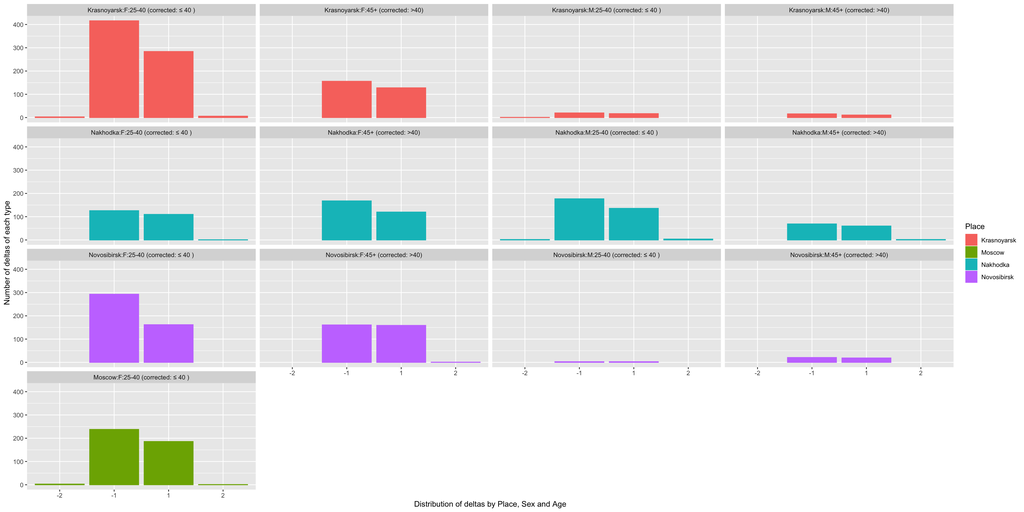

```r
Fig3
```

### Adjusting the unigram data for modelling

```r
data_ug <- zUg_Counted
row.names(data_ug) <- paste(data_ug$Speaker_ID,data_ug$Sentence)
data_ug$X1prop <- data_ug$"-1"/(data_ug$"0" + data_ug$"1" + data_ug$"-1" + 1)
data_ug <- mutate(data_ug, TextType = as.factor(ifelse(grepl("Experiment",Text),"dialogue","monologue")))
data_ug <- mutate(data_ug, Role = as.factor(ifelse(grepl("Follower",Text),"hearer","speaker")))
data_ug$Age_Group<-c("Low", "High")[
  findInterval(data_ug$Age , c(-Inf, 40, Inf) ) ]
data_ug$Text <- as.factor(data_ug$Text)
data_ug$Sex <- as.factor(data_ug$Sex)
data_ug$Age_Group <- as.factor(data_ug$Age_Group)
```

### The same for deltas

```r
data_dlt <- zDlt_Counted
row.names(data_dlt) <- paste(data_dlt$Speaker_ID,data_dlt$Sentence)
data_dlt$X0prop <- (data_dlt$"0")/(data_dlt$"1" + data_dlt$"-1" + data_dlt$"2" + data_dlt$"-2" + data_dlt$"0" + 1)
data_dlt <- mutate(data_dlt, TextType = as.factor(ifelse(grepl("Experiment",Text),"dialogue","monologue")))
data_dlt <- mutate(data_dlt, Role = as.factor(ifelse(grepl("Follower",Text),"hearer","speaker")))
data_dlt$Age_Group<-c("Low", "High")[
  findInterval(data_dlt$Age , c(-Inf, 40, Inf) ) ]
data_dlt$Text <- as.factor(data_dlt$Text)
data_dlt$Sex <- as.factor(data_dlt$Sex)
data_dlt$Age_Group <- as.factor(data_dlt$Age_Group)
```

## Modelling

### Model for -1 vs. other unigrams

```r
Data_counted <- data_ug
summary(model.0 <- lmer(X1prop ~ Sex*Age + Place + TextType + (1 | Speaker_ID), data = Data_counted, control = lmerControl(optimizer = "bobyqa")))
```

```
## Linear mixed model fit by REML. t-tests use Satterthwaite's method [
## lmerModLmerTest]
## Formula: X1prop ~ Sex * Age + Place + TextType + (1 | Speaker_ID)
##    Data: Data_counted
## Control: lmerControl(optimizer = "bobyqa")
##
## REML criterion at convergence: -548.9
##
## Scaled residuals:
##     Min      1Q  Median      3Q     Max
## -4.9164 -0.2972  0.0790  0.5523  2.7411
##
## Random effects:
##  Groups     Name        Variance Std.Dev.
##  Speaker_ID (Intercept) 0.01733  0.1317
##  Residual               0.03013  0.1736
## Number of obs: 1007, groups:  Speaker_ID, 26
##
## Fixed effects:
##                     Estimate Std. Error         df t value Pr(>|t|)
## (Intercept)         0.601353   0.114265  19.260845   5.263 4.25e-05 ***
## SexM                0.352244   0.158879  19.106768   2.217   0.0389 *
## Age                 0.003763   0.002866  19.163845   1.313   0.2048
## PlaceMoscow        -0.020298   0.120736  18.997443  -0.168   0.8683
## PlaceNakhodka      -0.077046   0.071215  18.961099  -1.082   0.2929
## PlaceNovosibirsk   -0.124351   0.067907  19.081400  -1.831   0.0827 .
## TextTypemonologue   0.028922   0.011270 980.597942   2.566   0.0104 *
## SexM:Age           -0.003494   0.003908  19.082356  -0.894   0.3825
## ---
## Signif. codes:  0 '***' 0.001 '**' 0.01 '*' 0.05 '.' 0.1 ' ' 1
##
## Correlation of Fixed Effects:
##             (Intr) SexM   Age    PlcMsc PlcNkh PlcNvs TxtTyp
## SexM        -0.684
## Age         -0.872  0.630
## PlaceMoscow -0.581  0.385  0.410
## PlaceNakhdk -0.117  0.049 -0.206  0.196
## PlacNvsbrsk -0.228  0.018 -0.081  0.249  0.510
## TextTypmnlg -0.057 -0.002 -0.004 -0.003  0.002  0.010
## SexM:Age     0.657 -0.938 -0.693 -0.334 -0.043 -0.016  0.001
```

```r
drop1(model.0, test = "Chisq") # The Sex:Age interaction can be dropped
```

|  | Sum Sq | Mean Sq | NumDF | DenDF | F value | Pr(>F) |
| --- | --- | --- | --- | --- | --- | --- |
| Place | 0.10486518 | 0.03495506 | 3 | 19.02904 | 1.1603188 | 0.35074702 |
| TextType | 0.19838942 | 0.19838942 | 1 | 980.59794 | 6.5854547 | 0.01042907 |
| Sex:Age | 0.02407386 | 0.02407386 | 1 | 19.08236 | 0.7991219 | 0.38249251 |

```r
summary(model.1 <- lmer(X1prop ~ Sex + Age + Place + TextType + (1 | Speaker_ID), data = Data_counted, control = lmerControl(optimizer = "bobyqa")))
```

```
## Linear mixed model fit by REML. t-tests use Satterthwaite's method [
## lmerModLmerTest]
## Formula: X1prop ~ Sex + Age + Place + TextType + (1 | Speaker_ID)
##    Data: Data_counted
## Control: lmerControl(optimizer = "bobyqa")
##
## REML criterion at convergence: -557.4
##
## Scaled residuals:
##     Min      1Q  Median      3Q     Max
## -4.9164 -0.3001  0.0776  0.5515  2.7325
##
## Random effects:
##  Groups     Name        Variance Std.Dev.
##  Speaker_ID (Intercept) 0.01714  0.1309
##  Residual               0.03013  0.1736
## Number of obs: 1007, groups:  Speaker_ID, 26
##
## Fixed effects:
##                     Estimate Std. Error         df t value Pr(>|t|)
## (Intercept)         0.668450   0.085700  20.251928   7.800 1.58e-07 ***
## SexM                0.219035   0.054830  19.993714   3.995 0.000712 ***
## Age                 0.001988   0.002056  20.062626   0.967 0.345174
## PlaceMoscow        -0.056337   0.113195  19.929449  -0.498 0.624142
## PlaceNakhodka      -0.079783   0.070766  19.929332  -1.127 0.272955
## PlaceNovosibirsk   -0.125299   0.067534  20.055830  -1.855 0.078307 .
## TextTypemonologue   0.028935   0.011270 980.580564   2.567 0.010395 *
## ---
## Signif. codes:  0 '***' 0.001 '**' 0.01 '*' 0.05 '.' 0.1 ' ' 1
##
## Correlation of Fixed Effects:
##             (Intr) SexM   Age    PlcMsc PlcNkh PlcNvs
## SexM        -0.258
## Age         -0.766 -0.078
## PlaceMoscow -0.509  0.220  0.263
## PlaceNakhdk -0.118  0.025 -0.327  0.193
## PlacNvsbrsk -0.289  0.008 -0.127  0.259  0.510
## TextTypmnlg -0.077 -0.004 -0.005 -0.002  0.002  0.010
```

```r
drop1(model.1, test = "Chisq") # Place can be dropped
```

|  | Sum Sq | Mean Sq | NumDF | DenDF | F value | Pr(>F) |
| --- | --- | --- | --- | --- | --- | --- |
| Sex | 0.48077010 | 0.48077010 | 1 | 19.99371 | 15.9587405 | 0.0007124314 |
| Age | 0.02815638 | 0.02815638 | 1 | 20.06263 | 0.9346264 | 0.3451739680 |
| Place | 0.10504962 | 0.03501654 | 3 | 19.98660 | 1.1623432 | 0.3487780180 |
| TextType | 0.19856768 | 0.19856768 | 1 | 980.58056 | 6.5912794 | 0.0103952408 |

```r
summary(model.2 <- lmer(X1prop ~ Sex + Age + TextType + (1 | Speaker_ID), data = Data_counted, control = lmerControl(optimizer = "bobyqa")))
```

```
## Linear mixed model fit by REML. t-tests use Satterthwaite's method [
## lmerModLmerTest]
## Formula: X1prop ~ Sex + Age + TextType + (1 | Speaker_ID)
##    Data: Data_counted
## Control: lmerControl(optimizer = "bobyqa")
##
## REML criterion at convergence: -563.8
##
## Scaled residuals:
##     Min      1Q  Median      3Q     Max
## -4.9182 -0.2901  0.0731  0.5555  2.7175
##
## Random effects:
##  Groups     Name        Variance Std.Dev.
##  Speaker_ID (Intercept) 0.01750  0.1323
##  Residual               0.03013  0.1736
## Number of obs: 1007, groups:  Speaker_ID, 26
##
## Fixed effects:
##                    Estimate Std. Error        df t value Pr(>|t|)
## (Intercept)       6.230e-01  7.294e-02 2.339e+01   8.541  1.2e-08 ***
## SexM              2.202e-01  5.395e-02 2.295e+01   4.082 0.000461 ***
## Age               1.372e-03  1.837e-03 2.299e+01   0.747 0.462869
## TextTypemonologue 2.912e-02  1.127e-02 9.808e+02   2.584 0.009902 **
## ---
## Signif. codes:  0 '***' 0.001 '**' 0.01 '*' 0.05 '.' 0.1 ' ' 1
##
## Correlation of Fixed Effects:
##             (Intr) SexM   Age
## SexM        -0.188
## Age         -0.863 -0.166
## TextTypmnlg -0.089 -0.003 -0.004
```

```r
drop1(model.2, test = "Chisq") # Age can be dropped
```

|  | Sum Sq | Mean Sq | NumDF | DenDF | F value | Pr(>F) |
| --- | --- | --- | --- | --- | --- | --- |
| Sex | 0.50198318 | 0.50198318 | 1 | 22.94570 | 16.662548 | 0.0004606298 |
| Age | 0.01679305 | 0.01679305 | 1 | 22.99277 | 0.557419 | 0.4628685027 |
| TextType | 0.20119595 | 0.20119595 | 1 | 980.77940 | 6.678385 | 0.0099024564 |

```r
anova(model.1, model.2) # No significant difference between the models
```

|  | Df | AIC | BIC | logLik | deviance | Chisq | Chi Df | Pr(>Chisq) |
| --- | --- | --- | --- | --- | --- | --- | --- | --- |
| model.2 | 6 | -579.3614 | -549.8731 | 295.6807 | -591.3614 | NA | NA | NA |
| model.1 | 9 | -577.5380 | -533.3054 | 297.7690 | -595.5380 | 4.176557 | 3 | 0.2430195 |

```r
summary(model.3 <- lmer(X1prop ~ Sex + TextType + (1 | Speaker_ID), data = Data_counted, control = lmerControl(optimizer = "bobyqa")))
```

```
## Linear mixed model fit by REML. t-tests use Satterthwaite's method [
## lmerModLmerTest]
## Formula: X1prop ~ Sex + TextType + (1 | Speaker_ID)
##    Data: Data_counted
## Control: lmerControl(optimizer = "bobyqa")
##
## REML criterion at convergence: -574
##
## Scaled residuals:
##     Min      1Q  Median      3Q     Max
## -4.9178 -0.2932  0.0758  0.5578  2.7112
##
## Random effects:
##  Groups     Name        Variance Std.Dev.
##  Speaker_ID (Intercept) 0.01716  0.1310
##  Residual               0.03013  0.1736
## Number of obs: 1007, groups:  Speaker_ID, 26
##
## Fixed effects:
##                    Estimate Std. Error        df t value Pr(>|t|)
## (Intercept)         0.67000    0.03645  25.71047  18.381 2.62e-16 ***
## SexM                0.22691    0.05269  23.92080   4.306 0.000244 ***
## TextTypemonologue   0.02916    0.01127 980.80429   2.588 0.009803 **
## ---
## Signif. codes:  0 '***' 0.001 '**' 0.01 '*' 0.05 '.' 0.1 ' ' 1
##
## Correlation of Fixed Effects:
##             (Intr) SexM
## SexM        -0.667
## TextTypmnlg -0.186 -0.004
```

```r
drop1(model.3, test = "Chisq") # Nothing can be dropped, still test against a simpler model
```

|  | Sum Sq | Mean Sq | NumDF | DenDF | F value | Pr(>F) |
| --- | --- | --- | --- | --- | --- | --- |
| Sex | 0.5586451 | 0.5586451 | 1 | 23.9208 | 18.543162 | 0.0002439525 |
| TextType | 0.2017414 | 0.2017414 | 1 | 980.8043 | 6.696422 | 0.0098034552 |

```r
summary(model.4 <- lmer(X1prop ~ Sex + (1 | Speaker_ID), data = Data_counted, control = lmerControl(optimizer = "bobyqa")))
```

```
## Linear mixed model fit by REML. t-tests use Satterthwaite's method [
## lmerModLmerTest]
## Formula: X1prop ~ Sex + (1 | Speaker_ID)
##    Data: Data_counted
## Control: lmerControl(optimizer = "bobyqa")
##
## REML criterion at convergence: -574.5
##
## Scaled residuals:
##     Min      1Q  Median      3Q     Max
## -5.0087 -0.2960  0.0857  0.5752  2.6748
##
## Random effects:
##  Groups     Name        Variance Std.Dev.
##  Speaker_ID (Intercept) 0.01728  0.1314
##  Residual               0.03030  0.1741
## Number of obs: 1007, groups:  Speaker_ID, 26
##
## Fixed effects:
##             Estimate Std. Error       df t value Pr(>|t|)
## (Intercept)  0.68751    0.03594 23.96336  19.129 5.08e-16 ***
## SexM         0.22740    0.05288 23.91599   4.301 0.000247 ***
## ---
## Signif. codes:  0 '***' 0.001 '**' 0.01 '*' 0.05 '.' 0.1 ' ' 1
##
## Correlation of Fixed Effects:
##      (Intr)
## SexM -0.680
```

```r
drop1(model.4, test = "Chisq")
```

|  | Sum Sq | Mean Sq | NumDF | DenDF | F value | Pr(>F) |
| --- | --- | --- | --- | --- | --- | --- |
| Sex | 0.5603618 | 0.5603618 | 1 | 23.91599 | 18.49587 | 0.0002474692 |

```r
anova(model.3, model.4) # Model 3 is significantly better, so use it as the final model
```

|  | Df | AIC | BIC | logLik | deviance | Chisq | Chi Df | Pr(>Chisq) |
| --- | --- | --- | --- | --- | --- | --- | --- | --- |
| model.4 | 4 | -576.0451 | -556.3862 | 292.0226 | -584.0451 | NA | NA | NA |
| model.3 | 5 | -580.7398 | -556.1661 | 295.3699 | -590.7398 | 6.694623 | 1 | 0.009670414 |

### Figure 4. The effect of biological sex and text type on the proportion of “−1” unigrams to “not −1” unigrams

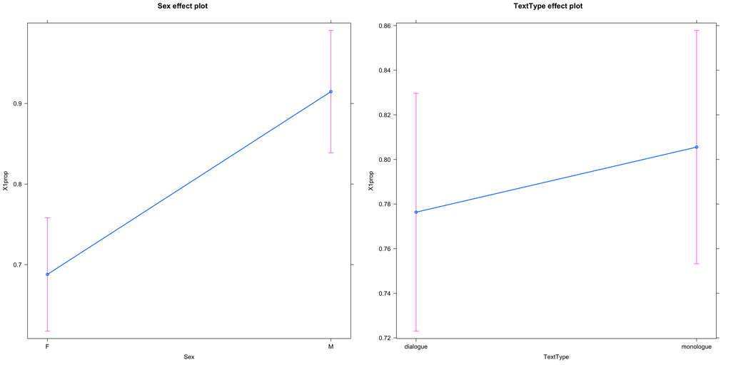

```r
plot(allEffects(model.3))
```

### Model for 0 vs. other deltas

```r
Data_counted <- data_dlt
summary(model.0 <- lmer(X0prop ~ Sex*Age + Place + Role + (1 | Speaker_ID), data = Data_counted, control = lmerControl(optimizer = "bobyqa")))
```

```
## Linear mixed model fit by REML. t-tests use Satterthwaite's method [
## lmerModLmerTest]
## Formula: X0prop ~ Sex * Age + Place + Role + (1 | Speaker_ID)
##    Data: Data_counted
## Control: lmerControl(optimizer = "bobyqa")
##
## REML criterion at convergence: -4613.3
##
## Scaled residuals:
##     Min      1Q  Median      3Q     Max
## -6.8432 -0.2343  0.1717  0.4730  2.5043
##
## Random effects:
##  Groups     Name        Variance  Std.Dev.
##  Speaker_ID (Intercept) 0.0001869 0.01367
##  Residual               0.0005205 0.02281
## Number of obs: 1007, groups:  Speaker_ID, 26
##
## Fixed effects:
##                    Estimate Std. Error         df t value Pr(>|t|)
## (Intercept)       9.508e-01  1.238e-02  2.162e+01  76.796   <2e-16 ***
## SexM              4.117e-02  1.673e-02  1.917e+01   2.461   0.0235 *
## Age               5.586e-04  3.018e-04  1.925e+01   1.851   0.0796 .
## PlaceMoscow      -1.748e-02  1.270e-02  1.902e+01  -1.376   0.1848
## PlaceNakhodka    -1.020e-02  7.499e-03  1.905e+01  -1.360   0.1899
## PlaceNovosibirsk -7.467e-03  7.146e-03  1.912e+01  -1.045   0.3091
## Rolespeaker      -3.137e-03  3.295e-03  9.984e+02  -0.952   0.3412
## SexM:Age         -6.060e-04  4.114e-04  1.913e+01  -1.473   0.1569
## ---
## Signif. codes:  0 '***' 0.001 '**' 0.01 '*' 0.05 '.' 0.1 ' ' 1
##
## Correlation of Fixed Effects:
##             (Intr) SexM   Age    PlcMsc PlcNkh PlcNvs Rlspkr
## SexM        -0.670
## Age         -0.843  0.630
## PlaceMoscow -0.573  0.386  0.410
## PlaceNakhdk -0.127  0.050 -0.207  0.198
## PlacNvsbrsk -0.216  0.017 -0.081  0.248  0.508
## Rolespeaker -0.243  0.023 -0.016  0.033  0.057 -0.016
## SexM:Age     0.644 -0.938 -0.693 -0.335 -0.044 -0.015 -0.023
```

```r
drop1(model.0) # Place can be dropped
```

|  | Sum Sq | Mean Sq | NumDF | DenDF | F value | Pr(>F) |
| --- | --- | --- | --- | --- | --- | --- |
| Place | 0.0016509034 | 0.0005503011 | 3 | 19.11572 | 1.0572626 | 0.3902853 |
| Role | 0.0004719301 | 0.0004719301 | 1 | 998.40051 | 0.9066928 | 0.3412239 |
| Sex:Age | 0.0011298023 | 0.0011298023 | 1 | 19.13471 | 2.1706256 | 0.1569296 |

```r
summary(model.1 <- lmer(X0prop ~ Sex*Age + Role + (1 | Speaker_ID), data = Data_counted, control = lmerControl(optimizer = "bobyqa")))
```

```
## Linear mixed model fit by REML. t-tests use Satterthwaite's method [
## lmerModLmerTest]
## Formula: X0prop ~ Sex * Age + Role + (1 | Speaker_ID)
##    Data: Data_counted
## Control: lmerControl(optimizer = "bobyqa")
##
## REML criterion at convergence: -4633.4
##
## Scaled residuals:
##     Min      1Q  Median      3Q     Max
## -6.8598 -0.2370  0.1719  0.4749  2.4881
##
## Random effects:
##  Groups     Name        Variance  Std.Dev.
##  Speaker_ID (Intercept) 0.0001883 0.01372
##  Residual               0.0005205 0.02281
## Number of obs: 1007, groups:  Speaker_ID, 26
##
## Fixed effects:
##               Estimate Std. Error         df t value Pr(>|t|)
## (Intercept)  9.407e-01  1.014e-02  2.592e+01  92.813  < 2e-16 ***
## SexM         4.927e-02  1.542e-02  2.206e+01   3.195  0.00417 **
## Age          6.270e-04  2.612e-04  2.214e+01   2.401  0.02520 *
## Rolespeaker -2.846e-03  3.284e-03  9.998e+02  -0.867  0.38638
## SexM:Age    -7.792e-04  3.879e-04  2.204e+01  -2.009  0.05695 .
## ---
## Signif. codes:  0 '***' 0.001 '**' 0.01 '*' 0.05 '.' 0.1 ' ' 1
##
## Correlation of Fixed Effects:
##             (Intr) SexM   Age    Rlspkr
## SexM        -0.608
## Age         -0.878  0.581
## Rolespeaker -0.280  0.008 -0.021
## SexM:Age     0.598 -0.930 -0.673 -0.010
```

```r
drop1(model.1) # Role can be dropped
```

|  | Sum Sq | Mean Sq | NumDF | DenDF | F value | Pr(>F) |
| --- | --- | --- | --- | --- | --- | --- |
| Role | 0.0003908687 | 0.0003908687 | 1 | 999.76155 | 0.7509472 | 0.38638443 |
| Sex:Age | 0.0021006075 | 0.0021006075 | 1 | 22.03706 | 4.0357422 | 0.05695258 |

```r
summary(model.2 <- lmer(X0prop ~ Sex*Age + (1 | Speaker_ID), data = Data_counted, control = lmerControl(optimizer = "bobyqa")))
```

```
## Linear mixed model fit by REML. t-tests use Satterthwaite's method [
## lmerModLmerTest]
## Formula: X0prop ~ Sex * Age + (1 | Speaker_ID)
##    Data: Data_counted
## Control: lmerControl(optimizer = "bobyqa")
##
## REML criterion at convergence: -4642.2
##
## Scaled residuals:
##     Min      1Q  Median      3Q     Max
## -6.9057 -0.2408  0.1747  0.4746  2.5669
##
## Random effects:
##  Groups     Name        Variance  Std.Dev.
##  Speaker_ID (Intercept) 0.0001848 0.01359
##  Residual               0.0005206 0.02282
## Number of obs: 1007, groups:  Speaker_ID, 26
##
## Fixed effects:
##               Estimate Std. Error         df t value Pr(>|t|)
## (Intercept)  0.9382139  0.0096444 22.2473439  97.281  < 2e-16 ***
## SexM         0.0493740  0.0152850 22.1623549   3.230  0.00382 **
## Age          0.0006223  0.0002588 22.2183259   2.405  0.02495 *
## SexM:Age    -0.0007826  0.0003844 22.1321434  -2.036  0.05393 .
## ---
## Signif. codes:  0 '***' 0.001 '**' 0.01 '*' 0.05 '.' 0.1 ' ' 1
##
## Correlation of Fixed Effects:
##          (Intr) SexM   Age
## SexM     -0.631
## Age      -0.921  0.581
## SexM:Age  0.620 -0.930 -0.673
```

```r
drop1(model.2) # The interaction is on the edge of significance, but still drop
```

|  | Sum Sq | Mean Sq | NumDF | DenDF | F value | Pr(>F) |
| --- | --- | --- | --- | --- | --- | --- |
| Sex:Age | 0.002157272 | 0.002157272 | 1 | 22.13214 | 4.144011 | 0.05392695 |

```r
anova(model.1, model.2) # No significant difference between the models, select the simpler one
```

|  | Df | AIC | BIC | logLik | deviance | Chisq | Chi Df | Pr(>Chisq) |
| --- | --- | --- | --- | --- | --- | --- | --- | --- |
| model.2 | 6 | -4678.254 | -4648.766 | 2345.127 | -4690.254 | NA | NA | NA |
| model.1 | 7 | -4676.938 | -4642.535 | 2345.469 | -4690.938 | 0.6832433 | 1 | 0.4084721 |

```r
summary(model.3 <- lmer(X0prop ~ Sex + Age + (1 | Speaker_ID), data = Data_counted, control = lmerControl(optimizer = "bobyqa")))
```

```
## Linear mixed model fit by REML. t-tests use Satterthwaite's method [
## lmerModLmerTest]
## Formula: X0prop ~ Sex + Age + (1 | Speaker_ID)
##    Data: Data_counted
## Control: lmerControl(optimizer = "bobyqa")
##
## REML criterion at convergence: -4652.2
##
## Scaled residuals:
##     Min      1Q  Median      3Q     Max
## -6.8891 -0.2419  0.1796  0.4756  2.5587
##
## Random effects:
##  Groups     Name        Variance  Std.Dev.
##  Speaker_ID (Intercept) 0.0002117 0.01455
##  Residual               0.0005206 0.02282
## Number of obs: 1007, groups:  Speaker_ID, 26
##
## Fixed effects:
##              Estimate Std. Error        df t value Pr(>|t|)
## (Intercept) 9.504e-01  8.065e-03 2.312e+01 117.845  < 2e-16 ***
## SexM        2.044e-02  5.987e-03 2.303e+01   3.415  0.00237 **
## Age         2.677e-04  2.039e-04 2.309e+01   1.313  0.20207
## ---
## Signif. codes:  0 '***' 0.001 '**' 0.01 '*' 0.05 '.' 0.1 ' ' 1
##
## Correlation of Fixed Effects:
##      (Intr) SexM
## SexM -0.189
## Age  -0.867 -0.166
```

```r
drop1(model.3) # Age can be dropped
```

|  | Sum Sq | Mean Sq | NumDF | DenDF | F value | Pr(>F) |
| --- | --- | --- | --- | --- | --- | --- |
| Sex | 0.0060694639 | 0.0060694639 | 1 | 23.02631 | 11.65884 | 0.002370841 |
| Age | 0.0008975215 | 0.0008975215 | 1 | 23.09125 | 1.72405 | 0.202072187 |

```r
summary(model.4 <- lmer(X0prop ~ Sex + (1 | Speaker_ID), data = Data_counted, control = lmerControl(optimizer = "bobyqa")))
```

```
## Linear mixed model fit by REML. t-tests use Satterthwaite's method [
## lmerModLmerTest]
## Formula: X0prop ~ Sex + (1 | Speaker_ID)
##    Data: Data_counted
## Control: lmerControl(optimizer = "bobyqa")
##
## REML criterion at convergence: -4665.6
##
## Scaled residuals:
##     Min      1Q  Median      3Q     Max
## -6.8875 -0.2365  0.1742  0.4798  2.5493
##
## Random effects:
##  Groups     Name        Variance  Std.Dev.
##  Speaker_ID (Intercept) 0.0002183 0.01478
##  Residual               0.0005206 0.02282
## Number of obs: 1007, groups:  Speaker_ID, 26
##
## Fixed effects:
##              Estimate Std. Error        df t value Pr(>|t|)
## (Intercept)  0.959556   0.004073 24.059565 235.611  < 2e-16 ***
## SexM         0.021753   0.005991 23.996874   3.631  0.00133 **
## ---
## Signif. codes:  0 '***' 0.001 '**' 0.01 '*' 0.05 '.' 0.1 ' ' 1
##
## Correlation of Fixed Effects:
##      (Intr)
## SexM -0.680
```

```r
drop1(model.4) # Nothing can be dropped
```

|  | Sum Sq | Mean Sq | NumDF | DenDF | F value | Pr(>F) |
| --- | --- | --- | --- | --- | --- | --- |
| Sex | 0.006864005 | 0.006864005 | 1 | 23.99687 | 13.18492 | 0.001330684 |

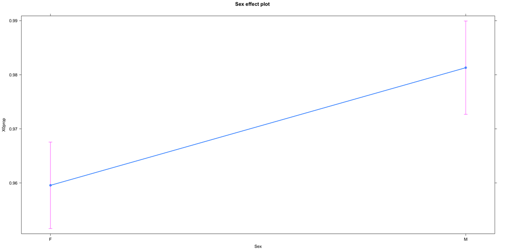

```r
plot(allEffects(model.4))
```

### Model for -1 vs. other unigrams by sex and age and type of text, with place as random effect

```r
Data_counted <- data_ug
summary(model.0 <- lmer(X1prop ~ Sex*Age + TextType + (1 | Place), data = Data_counted, control = lmerControl(optimizer = "bobyqa")))
```

```
## Linear mixed model fit by REML. t-tests use Satterthwaite's method [
## lmerModLmerTest]
## Formula: X1prop ~ Sex * Age + TextType + (1 | Place)
##    Data: Data_counted
## Control: lmerControl(optimizer = "bobyqa")
##
## REML criterion at convergence: -261.3
##
## Scaled residuals:
##     Min      1Q  Median      3Q     Max
## -4.2585 -0.3580  0.2147  0.6129  1.6948
##
## Random effects:
##  Groups   Name        Variance Std.Dev.
##  Place    (Intercept) 0.002685 0.05182
##  Residual             0.042974 0.20730
## Number of obs: 1007, groups:  Place, 4
##
## Fixed effects:
##                     Estimate Std. Error         df t value Pr(>|t|)
## (Intercept)        5.622e-01  3.692e-02  1.021e+01  15.225 2.37e-08 ***
## SexM               3.225e-01  3.946e-02  8.264e+02   8.173 1.12e-15 ***
## Age                3.311e-03  7.129e-04  6.160e+02   4.644 4.18e-06 ***
## TextTypemonologue  3.096e-02  1.342e-02  9.994e+02   2.306  0.02131 *
## SexM:Age          -2.898e-03  9.696e-04  8.998e+02  -2.989  0.00288 **
## ---
## Signif. codes:  0 '***' 0.001 '**' 0.01 '*' 0.05 '.' 0.1 ' ' 1
##
## Correlation of Fixed Effects:
##             (Intr) SexM   Age    TxtTyp
## SexM        -0.447
## Age         -0.629  0.630
## TextTypmnlg -0.213 -0.005 -0.013
## SexM:Age     0.440 -0.939 -0.696  0.000
```

```r
drop1(model.0, test = "Chisq") # Can't drop anything, all effects significant
```

|  | Sum Sq | Mean Sq | NumDF | DenDF | F value | Pr(>F) |
| --- | --- | --- | --- | --- | --- | --- |
| TextType | 0.2285255 | 0.2285255 | 1 | 999.4311 | 5.317797 | 0.021312600 |
| Sex:Age | 0.3838247 | 0.3838247 | 1 | 899.8176 | 8.931617 | 0.002878937 |

### Figure 6. Effect of age by sex and text type on the proportion of “−1” unigrams

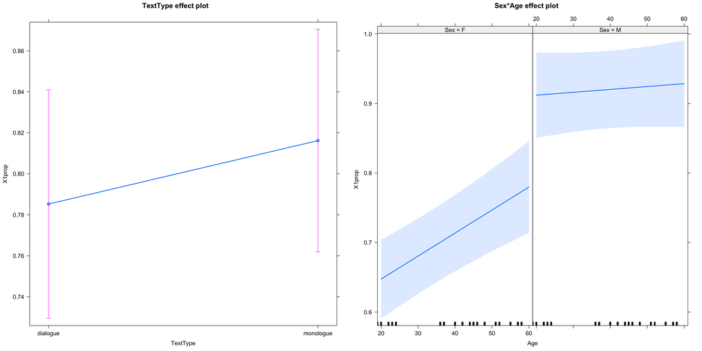

```r
plot(allEffects(model.0))
```